# Training NFL Spread Pool Models for the 2023 Season

David Cohn

2023-09-14

My aim is to develop one or more regression models using the caret package that predict the point margin of NFL games based on a) their final point spread (as of Sunday morning, for most games), and b) the difference in DAVE between the two teams. See the README for more information on the rationale and methodology.

The dataset that I have available for developing these models contains (almost) every game from the 2020, 2021, and 2022 NFL regular seasons. I used spreadsheets to record information about each game before making my picks in those years, including the final betting line and the difference in DAVE. I did switch to using Weighted DVOA in each season once that metric became available - usually around the midpoint of the season.

I’ll use the read_sheet() function from the googlesheets4 package to load the data from those Google sheets into R.

```r
read_nfl_predictor_sheet <- function(sheet_id) {
  sheet_data <- read_sheet(sheet_id) %>%
    select(
      `Week`, `OFP Line`, `Final Betting Line`, `DAVE Difference`, `Outcome`
    ) %>%
    filter(if_all(everything(), ~ !is.na(.x)))

  return(sheet_data)
}

game_data <- map(sheet_ids, read_nfl_predictor_sheet) %>%
  bind_rows()

game_data %>%
  slice_head(n = 5) %>%
  kbl(
    align = rep("c", ncol(game_data)),
    caption = 'Initial rows of the "game_data" table',
    digits = 2,
    col.names = c(
      "Week", "Pool Spread", "Final Spread", "DAVE Difference", "Actual Margin"
    )
  ) %>%
  kable_styling(
    bootstrap_options = c("striped", "hover", "condensed", "responsive")
  )
```

Initial rows of the “game_data” table

| Week | Pool Spread | Final Spread | DAVE Difference | Actual Margin |
| --- | --- | --- | --- | --- |
| 1 | -2.5 | -2.0 | -0.05 | -21 |
| 1 | -5.5 | -5.5 | -0.16 | -1 |
| 1 | -6.5 | -6.5 | -0.05 | 9 |
| 1 | 6.5 | 7.0 | 0.04 | -3 |
| 1 | -3.5 | -5.5 | -0.15 | -3 |

I’ll split this dataset 80/20 into training and test datasets. Because I used slightly different metrics at different points in the season, and because I expect the home-field advantage to vary over the course of the season, I’ll ensure that the two datasets contain similar proportions of games from each week.

```r
set.seed(508) # Brett Favre - career TD passes

features <- select(game_data, `Final Betting Line`, `DAVE Difference`) %>%
  as.data.frame()
responses <- as.data.frame(game_data$Outcome)

train_indices <- createDataPartition(game_data$Week, p = 0.8, list = FALSE)
train_features <- features[train_indices, ]
train_responses <- responses[train_indices]
test_features <- features[-train_indices, ]
test_responses <- responses[-train_indices]
```

Because points are scored in discrete chunks in football (typically 3 and 7), I don’t anticipate the expected point margin in a game to be proportional to the difference in quality between the two teams. Thus I’ll try training a non-linear model first, namely a random forest regression model.

I’ll tune the following hyperparameters using repeated 10-fold cross-validation:

- mtry: the number of randomly chosen features that each node can choose from to split observations
- min.node.size: the minimum number of observations that a node must contain for it to be split
- splitrule: the method that each node uses to determine which breakpoint to use when splitting

```r
get_rf_cv_results <- function(n_trees, grid) {
  rf_fit <- train(
    x = train_features,
    y = train_responses,
    method = "ranger",
    trControl = trainControl(method = "repeatedcv", number = 10, repeats = 5),
    tuneGrid = grid,
    num.trees = n_trees
  )

  rf_fit_results <- rf_fit$results %>%
    mutate(num.trees = n_trees) %>%
    select(num.trees, mtry, min.node.size, splitrule, RMSE)

  return(rf_fit_results)
}
```

And now I can define a hyperparameter grid and proceed with the tuning.

```r
rf_tuning_grid <- expand.grid(
  mtry = 1:2,
  min.node.size = seq(from = 1, by = 2, to = 15),
  splitrule = c("variance", "extratrees", "maxstat")
)

rf_hyperparam_opt_results <-
  get_rf_cv_results(n_trees = 100, grid = rf_tuning_grid)

slice_min(rf_hyperparam_opt_results, order_by = RMSE, n = 10) %>%
  kbl(
    align = rep("c", ncol(rf_hyperparam_opt_results)),
    caption = 'Random forest hyperparameter tuning results',
    digits = 3
  ) %>%
  kable_styling(
    bootstrap_options = c("striped", "hover", "condensed", "responsive")
  )
```

Random forest hyperparameter tuning results

| num.trees | mtry | min.node.size | splitrule | RMSE |
| --- | --- | --- | --- | --- |
| 100 | 1 | 13 | maxstat | 12.383 |
| 100 | 1 | 15 | maxstat | 12.384 |
| 100 | 1 | 11 | maxstat | 12.391 |
| 100 | 1 | 5 | maxstat | 12.405 |
| 100 | 1 | 7 | maxstat | 12.405 |
| 100 | 1 | 3 | maxstat | 12.406 |
| 100 | 1 | 9 | maxstat | 12.409 |
| 100 | 1 | 1 | maxstat | 12.425 |
| 100 | 2 | 15 | maxstat | 12.428 |
| 100 | 2 | 13 | maxstat | 12.452 |

Well, it’s pretty clear that it’s optimal to have mtry = 1 and splitrule = maxstat. Changes to min.node.size don’t seem to substantially impact the RMSE, so I’ll just use the default value for regression random forests, which is 5.

With those hyperparameters set, I’ll now tune the number of trees grown for the model.

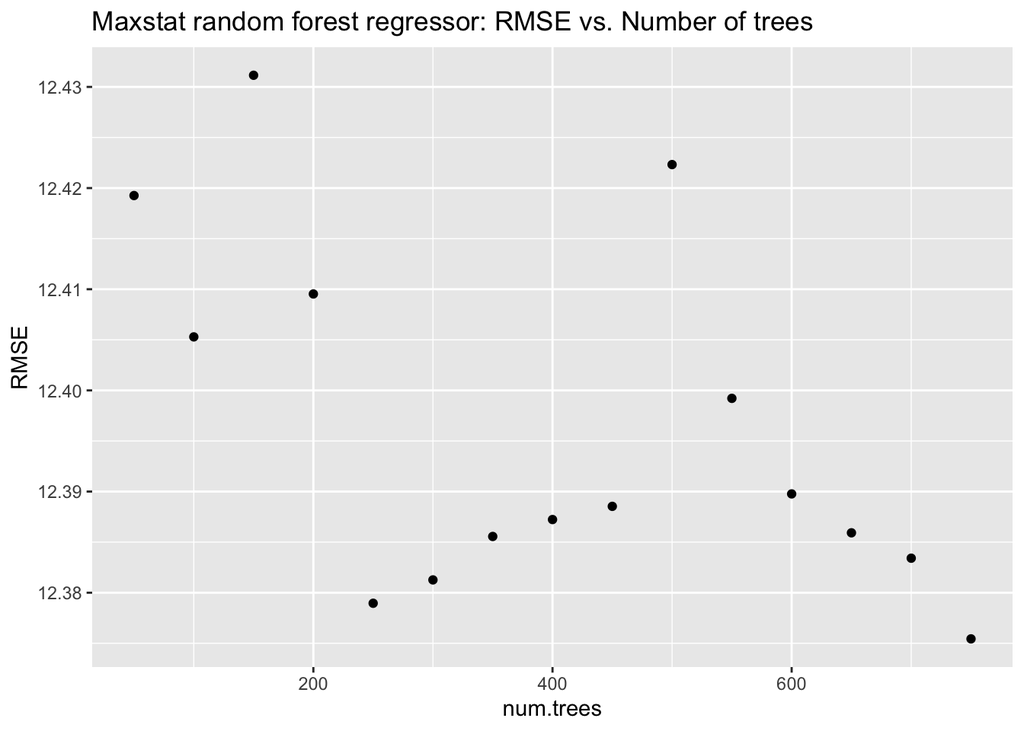

```r
rf_chosen_hyperparameters <- expand.grid(
  mtry = 1,
  min.node.size = 5,
  splitrule = "maxstat"
)
num_trees_tuning_values <- seq(from = 50, by = 50, to = 750)

rf_results_by_n_trees <- map(
  num_trees_tuning_values, get_rf_cv_results, grid = rf_chosen_hyperparameters
) %>%
  bind_rows()

ggplot(rf_results_by_n_trees) +
  geom_point(mapping = aes(x = num.trees, y = RMSE)) +
  ggtitle("Maxstat random forest regressor: RMSE vs. Number of trees")
```

The RMSE bounces around a bit as num.trees is increased, but there’s no real consistent downward trend. Given that the model is only using two features, it seems reasonable to just take num.trees = 50.

With all of the hyperparameters set, I can now train the final random forest regressor.

```r
rf_maxstat_model <- train(
  x = train_features,
  y = train_responses,
  method = "ranger",
  trControl = trainControl(method = "none"),
  tuneGrid = rf_chosen_hyperparameters,
  num.trees = 50
)
```

I’ll also train a random forest regressor that uses the “variance” splitrule. It wasn’t the optimal choice, but it is the default option, and I’m curious to see how it performs in comparison to our “maxstat” regressor.

I’ll first check what the optimal hyperparameters for that regressor are.

```r
rf_hyperparam_opt_results %>%
  filter(splitrule == "variance") %>%
  slice_min(order_by = RMSE, n = 10) %>%
  kbl(
    align = rep("c", ncol(rf_hyperparam_opt_results)),
    caption = 'Random forest hyperparameter tuning results ("variance" only)',
    digits = 3
  ) %>%
  kable_styling(
    bootstrap_options = c("striped", "hover", "condensed", "responsive")
  )
```

Random forest hyperparameter tuning results (“variance” only)

| num.trees | mtry | min.node.size | splitrule | RMSE |
| --- | --- | --- | --- | --- |
| 100 | 1 | 15 | variance | 13.040 |
| 100 | 1 | 13 | variance | 13.140 |
| 100 | 1 | 11 | variance | 13.211 |
| 100 | 1 | 9 | variance | 13.284 |
| 100 | 2 | 15 | variance | 13.296 |
| 100 | 2 | 13 | variance | 13.373 |
| 100 | 1 | 7 | variance | 13.396 |
| 100 | 1 | 5 | variance | 13.491 |
| 100 | 2 | 11 | variance | 13.526 |
| 100 | 1 | 3 | variance | 13.583 |

It still appears that mtry = 1 is optimal. This time though there’s a steady decrease in the RMSE as min.node.size is increased, so I’ll try the largest value: min.node.size = 15.

With those hyperparameters set, I’ll now tune the number of trees grown for the model.

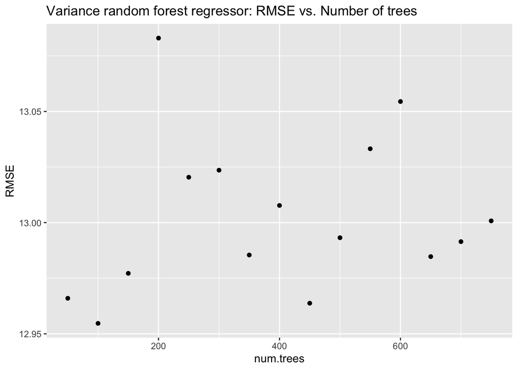

```r
variance_rf_chosen_hyperparameters <- expand.grid(
  mtry = 1,
  min.node.size = 15,
  splitrule = "variance"
)

variance_rf_results_by_n_trees <- map(
  num_trees_tuning_values, get_rf_cv_results,
  grid = variance_rf_chosen_hyperparameters
) %>%
  bind_rows()

ggplot(variance_rf_results_by_n_trees) +
  geom_point(mapping = aes(x = num.trees, y = RMSE)) +
  ggtitle("Variance random forest regressor: RMSE vs. Number of trees")
```

It’s even clearer here that the RMSE doesn’t decrease as num.trees is increased. So I’ll only grow 50 trees for this model too.

I can now train the final “variance” random forest regressor.

```r
rf_variance_model <- train(
  x = train_features,
  y = train_responses,
  method = "ranger",
  trControl = trainControl(method = "none"),
  tuneGrid = variance_rf_chosen_hyperparameters,
  num.trees = 50
)
```

While there are reasons to expect the relationship between relative team quality and final scoring margin to be non-linear, it seems reasonably likely that the dataset is not going to be large enough to train models that can accurately capture that non-linearity. There’s a risk that non-linear models will instead overfit to noise, and so this provides a rationale to also try training linear models, as they should be more robust to this type of overfitting.

I’ll start by training a group of basic linear regression models:

- one that uses only the difference in DAVE between teams
- one that uses only the final point spread of the game
- one that uses both of these features

```r
training_set <- game_data[train_indices, ]

dave_only_lm <- lm(Outcome ~ `DAVE Difference`, training_set)
line_only_lm <- lm(Outcome ~ `Final Betting Line`, training_set)
dave_and_line_lm <- lm(
  Outcome ~ `Final Betting Line` + `DAVE Difference`, training_set
)
```

I’ll also train a couple of support vector regression (SVR) models. The caret package includes both the svmLinear2 and svmLinear3 models, so I’ll try both, starting with svmLinear2.

The only hyperparameter to tune here is cost, which represents the size of the penalty associated with incorrect estimations of outcomes within the training dataset. In other words, a larger cost will cause the model to fit more tightly to the training dataset, while a smaller cost will have the opposite effect.

NOTE: I realized afterward that I probably should have also tuned the epsilon hyperparameter, as I did for the svmLinear3 model below. This may explain why this svmLinear2 model ultimately performed so poorly. Because I only set the random seed once at the start of this document, I can’t go back now and tune epsilon for this model as well without impacting the svmLinear3 model as well. I’ve already made predictions for week 1 using the final svmLinear3 model, so that’s not an option.

```r
svm2_cv <- train(
  x = train_features,
  y = train_responses,
  method = "svmLinear2",
  trControl = trainControl(method = "repeatedcv", number = 10, repeats = 5),
  tuneGrid = expand.grid(cost = seq(from = 0.25, by = 0.25, to = 1.5))
)

svm2_cv$results %>%
  select(cost, RMSE) %>%
  arrange(RMSE) %>%
  kbl(
    align = rep("c", ncol(svm2_cv$results)),
    caption = 'svm2Linear hyperparameter tuning results',
    digits = 4
  ) %>%
  kable_styling(
    bootstrap_options = c("striped", "hover", "condensed", "responsive")
  )
```

svm2Linear hyperparameter tuning results

| cost | RMSE |
| --- | --- |
| 0.50 | 12.2438 |
| 0.25 | 12.2439 |
| 1.50 | 12.2443 |
| 0.75 | 12.2444 |
| 1.00 | 12.2446 |
| 1.25 | 12.2451 |

It looks like the cross-validation RMSE is minimized (barely) when cost = 0.5, so I’ll use that value to train the final svmLinear2 model.

```r
svm2_model <- train(
  x = train_features,
  y = train_responses,
  method = "svmLinear2",
  trControl = trainControl(method = "none"),
  tuneGrid = expand.grid(cost = 0.5)
)
```

Now I can move on to an svmLinear3 model, which will be the last model that I train.

In addition to the cost hyperparameter, this model has two others:

- svr_eps: defines a tolerance margin - errors of less than this amount will not contribute to the total loss
- Loss: either L1 (sum of absolute residuals) or L2 (sum of squared residuals). Since we’re seeking to minimize RMSE in all of our other models, let’s just choose to always use an L2 loss function here, rather than tuning the hyperparameter.

```r
tune_svm3_with_epsilon <- function(epsilon) {
  svm3_cv <- train(
    x = train_features,
    y = train_responses,
    method = "svmLinear3",
    trControl = trainControl(method = "repeatedcv", number = 10, repeats = 5),
    tuneGrid = expand.grid(
      cost = seq(from = 0.25, by = 0.25, to = 1.5), Loss = "L2"
    ),
    svr_eps = epsilon
  )

  svm3_cv_results <- svm3_cv$results %>%
    mutate(svr_eps = epsilon) %>%
    select(cost, svr_eps, RMSE)

  return(svm3_cv_results)
}

svr_eps_grid <- c(0.02, 0.1, 0.5, 1, 2)

svm3_tuning_results <- map(svr_eps_grid, tune_svm3_with_epsilon) %>%
  bind_rows()

svm3_tuning_results %>%
  slice_min(order_by = RMSE, n = 10) %>%
  kbl(
    align = rep("c", ncol(svm3_tuning_results)),
    caption = 'svm3Linear hyperparameter tuning results',
    digits = 3
  ) %>%
  kable_styling(
    bootstrap_options = c("striped", "hover", "condensed", "responsive")
  )
```

svm3Linear hyperparameter tuning results

| cost | svr_eps | RMSE |
| --- | --- | --- |
| 0.25 | 0.1 | 12.207 |
| 1.25 | 0.1 | 12.212 |
| 0.25 | 0.5 | 12.213 |
| 1.00 | 0.1 | 12.214 |
| 0.50 | 0.1 | 12.215 |
| 0.75 | 0.1 | 12.216 |
| 1.50 | 0.1 | 12.219 |
| 0.25 | 1.0 | 12.220 |
| 1.25 | 0.5 | 12.221 |
| 0.50 | 1.0 | 12.222 |

The lowest RMSE comes about when cost = 0.25 and svr_eps = 0.1, so I’ll use those values to train the final version of this model.

```r
svmlinear3_chosen_hyperparameters <- expand.grid(cost = 0.25, Loss = "L2")

svm3_model <- train(
  x = train_features,
  y = train_responses,
  method = "svmLinear3",
  trControl = trainControl(method = "none"),
  tuneGrid = svmlinear3_chosen_hyperparameters,
  svr_eps = 0.1
)
```

I now have a set of seven different models - two random forest regression models, three linear regression models, and two support vector regressors.

```r
models <- list(
  "DAVE LM" = dave_only_lm, "Spread LM" = line_only_lm,
  "DAVE + Spread LM" = dave_and_line_lm, "Maxstat RF" = rf_maxstat_model,
  "Variance RF" = rf_variance_model, "SVM2" = svm2_model, "SVM3" = svm3_model
)
```

Before I test them on our test dataset, I’ll use each model to make predictions on some fake data that spans a wide range of point spreads and DAVE differences.

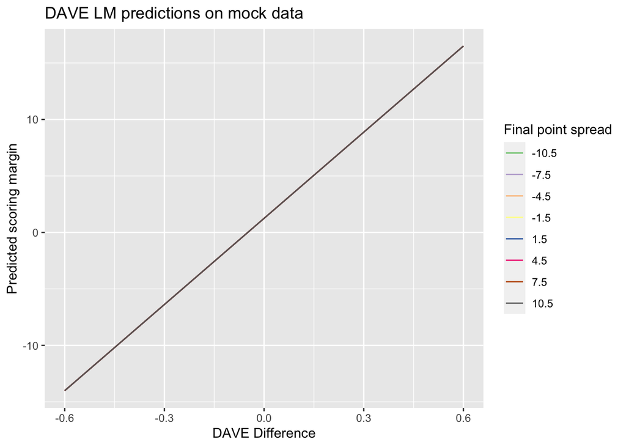

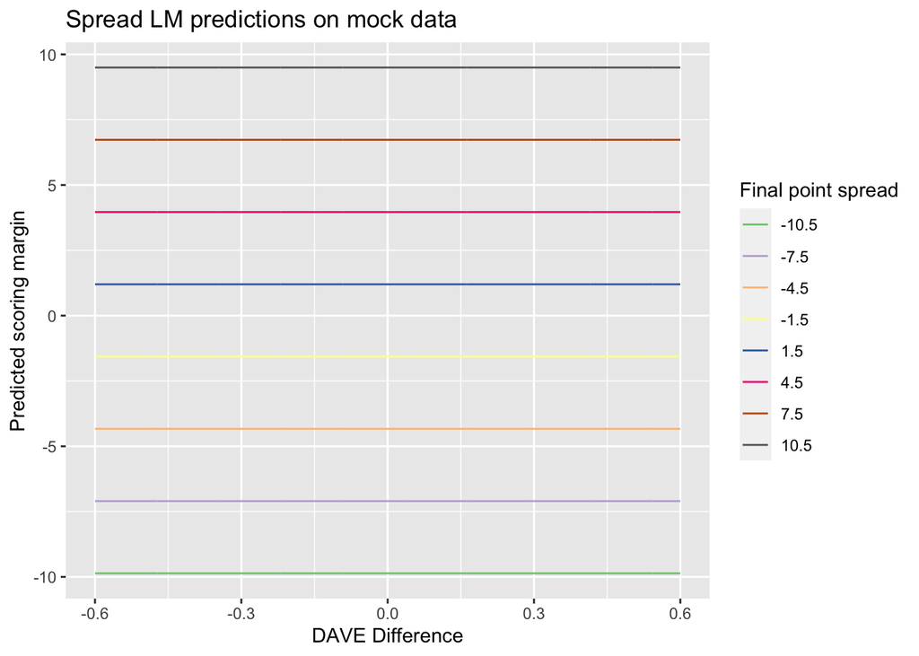

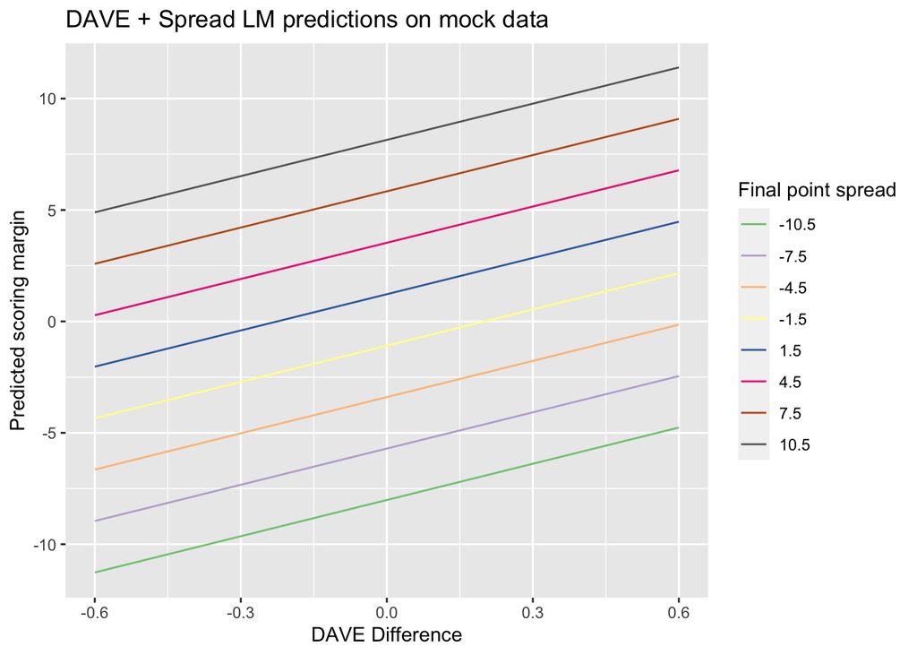

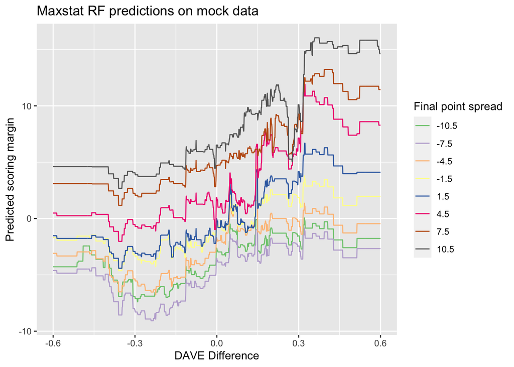

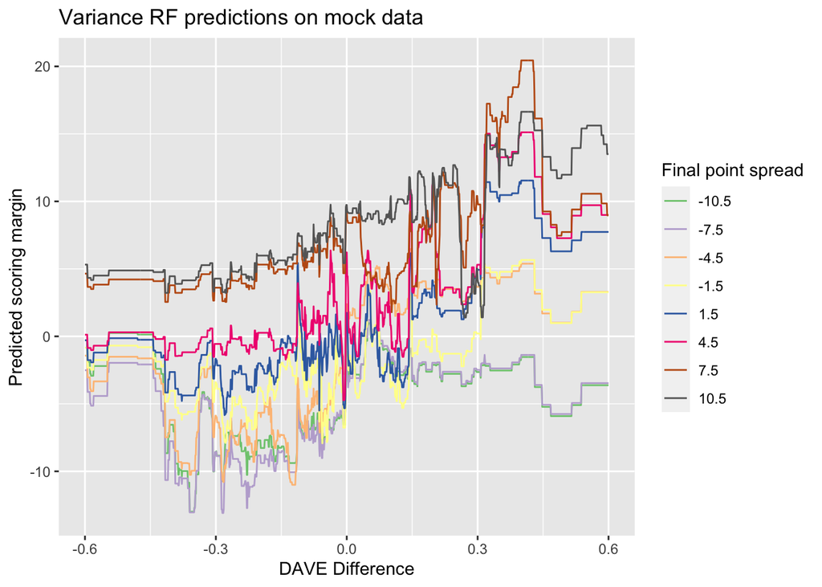

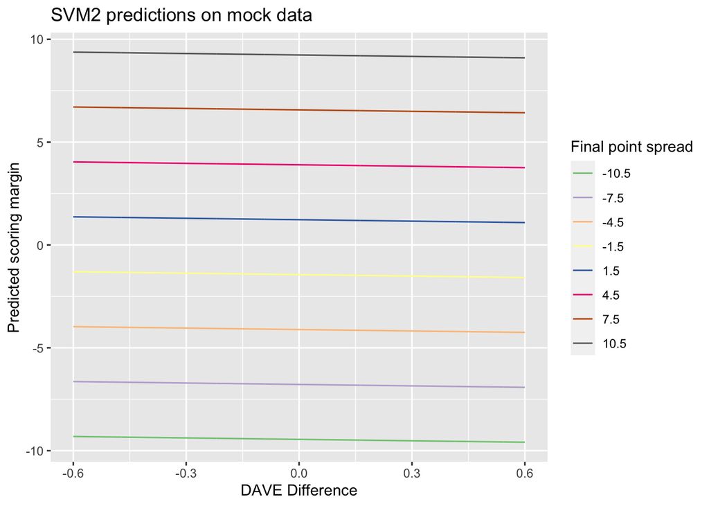

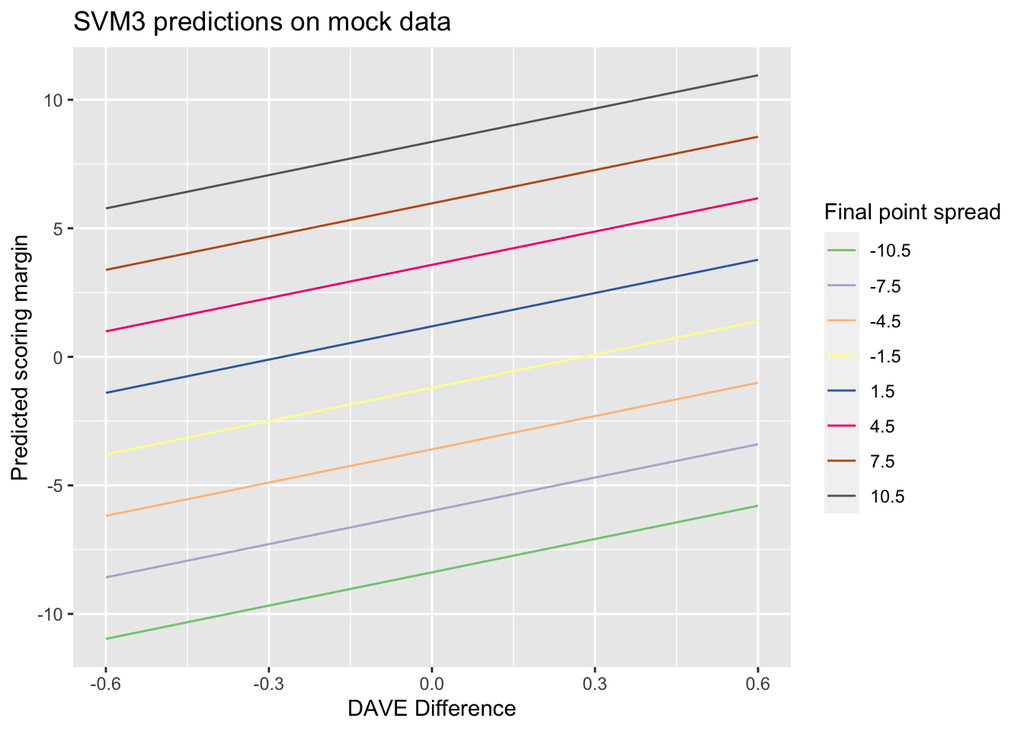

```r
mock_spreads <- seq(from = -10.5, by = 3, to = 10.5)
mock_DAVE_differences <- seq(from = -0.6, by = 0.001, to = 0.6)
mock_data <- crossing(mock_spreads, mock_DAVE_differences) %>%
  rename(
    `Final Betting Line` = mock_spreads,
    `DAVE Difference` = mock_DAVE_differences
  )

assess_model_on_mock_data <- function(model, model_name) {
  mock_predictions <- mock_data %>%
    mutate(prediction = predict(model, newdata = mock_data))

  assessment <- ggplot(
    mock_predictions,
    mapping = aes(
      x = `DAVE Difference`,
      y = prediction,
      color = as.factor(`Final Betting Line`)
    )
  ) +
    geom_line() +
    scale_color_brewer(type = "qual") +
    labs(
      title = glue("{model_name} predictions on mock data"),
      y = "Predicted scoring margin",
      color = "Final point spread"
    )

  print(assessment)
}

walk2(models, names(models), assess_model_on_mock_data)
```

For the most part these models are doing what I’d expect them to, but there are a couple of things that are worth noting.

First, the random forest models really appear to be overfit. Their predicted scoring margin isn’t even close to being a monotonic function of the DAVE difference (or of the final point spread), and there are areas where small changes in the DAVE difference cause the predicted scoring margin to spike. That being said, the maxstat random forest model certainly appears to be *less* of an overfit mess than the variance random forest model. I guess our tuning worked!

Second, something has gone quite wrong with the SVM2 model. Its predictions are almost independent of the DAVE difference, and if anything it appears that it predicts teams with superior DAVE to do slightly *worse*. This might relate to me having forgotten to tune the epsilon parameter for this model (see my note above).

Next, I’ll take a look at how each of these models performs on the **training** dataset. This will give me some further insight into whether any of the models are likely to be overfit, and whether any of them have picked up tendencies that are likely to diminish their predictive power (e.g. having a strong bias for or against home teams or favourites).

```r
report_model_stats_on_dataset <- function(model, name, dataset) {
  dataset <- mutate(
    dataset,
    prediction = predict(model, dataset),
    line_movement = `Final Betting Line` - `OFP Line`,
    picked_home = prediction > `OFP Line`,
    picked_favourite = (picked_home == (`OFP Line` > 0)),
    picked_line_movement = if_else(
      line_movement != 0, picked_home == (line_movement > 0), NA
    ),
    picked_correctly = (picked_home == (Outcome > `OFP Line`))
  )

  overall_win_rate <- mean(dataset$picked_correctly)
  home_pick_rate <- mean(dataset$picked_home)
  home_pick_win_rate <- dataset %>%
    filter(picked_home) %>%
    pull(picked_correctly) %>%
    mean()
  favourite_pick_rate <- mean(dataset$picked_favourite)
  favourite_pick_win_rate <- dataset %>%
    filter(picked_favourite) %>%
    pull(picked_correctly) %>%
    mean()
  movement_pick_rate <- mean(dataset$picked_line_movement, na.rm = TRUE)
  movement_pick_win_rate <- dataset %>%
    filter(picked_line_movement) %>%
    pull(picked_correctly) %>%
    mean()
  no_movement_win_rate <- dataset %>%
    filter(line_movement == 0) %>%
    pull(picked_correctly) %>%
    mean()

  return(
    tibble(
      name, overall_win_rate, home_pick_rate, home_pick_win_rate,
      favourite_pick_rate, favourite_pick_win_rate, movement_pick_rate,
      movement_pick_win_rate, no_movement_win_rate
    )
  )
}

model_performance_on_training_set <- map2(
  models, names(models), report_model_stats_on_dataset, dataset = training_set
) %>%
  bind_rows()

model_performance_on_training_set %>%
  kbl(
    align = rep("c", ncol(model_performance_on_training_set)),
    caption = "Performance of all models on the training set",
    digits = 3,
    col.names = c(
      "Model", "Win rate", "Home pick rate", "Win rate (picking home teams)",
      "Favourite pick rate", "Win rate (picking favourites)",
      "Line movement pick rate", "Win rate (picking with line movement)",
      "Win rate (no line movement)")
  ) %>%
  kable_styling(
    bootstrap_options = c("striped", "hover", "condensed", "responsive")
  )
```

Performance of all models on the training set

| Model | Win rate | Home pick rate | Win rate (picking home teams) | Favourite pick rate | Win rate (picking favourites) | Line movement pick rate | Win rate (picking with line movement) | Win rate (no line movement) |
| --- | --- | --- | --- | --- | --- | --- | --- | --- |
| DAVE LM | 0.525 | 0.456 | 0.510 | 0.233 | 0.466 | 0.572 | 0.554 | 0.496 |
| Spread LM | 0.555 | 0.391 | 0.551 | 0.282 | 0.525 | 0.891 | 0.546 | 0.575 |
| DAVE + Spread LM | 0.569 | 0.367 | 0.574 | 0.297 | 0.548 | 0.839 | 0.564 | 0.540 |
| Maxstat RF | 0.656 | 0.386 | 0.682 | 0.329 | 0.675 | 0.665 | 0.649 | 0.602 |
| Variance RF | 0.740 | 0.416 | 0.770 | 0.416 | 0.739 | 0.625 | 0.726 | 0.690 |
| SVM2 | 0.552 | 0.394 | 0.547 | 0.228 | 0.524 | 0.833 | 0.549 | 0.558 |
| SVM3 | 0.563 | 0.357 | 0.567 | 0.287 | 0.539 | 0.848 | 0.560 | 0.531 |

This largely confirms what I saw before. The two RF models have unrealistically high win rates on the training set, with the variance RF being worse, which suggests overfitting. The other models all achieve more reasonable win rates and have a stronger bias towards picking teams with favourable line movement (save for the DAVE-only model), which is encouraging.

Based on these stats and the mock data predictions, I’m expecting either the DAVE + Spread linear model or the SVM3 model to have the best performance on the test data. Time to find out!

```r
test_set <- game_data[-train_indices, ]

model_performance_on_test_set <- map2(
  models, names(models), report_model_stats_on_dataset, dataset = test_set
) %>%
  bind_rows()

model_performance_on_test_set %>%
  kbl(
    align = rep("c", ncol(model_performance_on_test_set)),
    caption = "Performance of all models on the test set",
    digits = 3,
    col.names = c(
      "Model", "Win rate", "Home pick rate", "Win rate (picking home teams)",
      "Favourite pick rate", "Win rate (picking favourites)",
      "Line movement pick rate", "Win rate (picking with line movement)",
      "Win rate (no line movement)")
  ) %>%
  kable_styling(
    bootstrap_options = c("striped", "hover", "condensed", "responsive")
  )
```

Performance of all models on the test set

| Model | Win rate | Home pick rate | Win rate (picking home teams) | Favourite pick rate | Win rate (picking favourites) | Line movement pick rate | Win rate (picking with line movement) | Win rate (no line movement) |
| --- | --- | --- | --- | --- | --- | --- | --- | --- |
| DAVE LM | 0.561 | 0.497 | 0.584 | 0.284 | 0.591 | 0.500 | 0.631 | 0.52 |
| Spread LM | 0.510 | 0.368 | 0.544 | 0.284 | 0.500 | 0.846 | 0.555 | 0.40 |
| DAVE + Spread LM | 0.529 | 0.361 | 0.571 | 0.342 | 0.528 | 0.808 | 0.562 | 0.48 |
| Maxstat RF | 0.606 | 0.490 | 0.632 | 0.432 | 0.612 | 0.592 | 0.649 | 0.56 |
| Variance RF | 0.587 | 0.484 | 0.613 | 0.452 | 0.586 | 0.562 | 0.644 | 0.52 |
| SVM2 | 0.477 | 0.374 | 0.500 | 0.252 | 0.436 | 0.808 | 0.533 | 0.40 |
| SVM3 | 0.542 | 0.323 | 0.600 | 0.316 | 0.551 | 0.808 | 0.581 | 0.40 |

This is … not what I expected. I really don’t understand how the random forest models, which seemed to be overfitting like crazy, are performing so well on the test dataset. We do see that the SVM2 model is worthless (48% win rate), which does make sense.

Even though the random forest models performed well here, I’m still very wary of using them for my picks this year. My plan is to primarily use the DAVE + Spread LM and the SVM3 model, both of which make use of both features, are reasonably explainable, usually pick with line movement, and performed adequately (53-54%) on the test dataset. I’ll hold on to the Maxstat RF model and track how it does over the course of the season out of curiousity, but I really don’t trust it. And finally, while the DAVE-only linear model looks great here (56% win rate), I know that line movement does offer predictive power, and so I don’t want to exclude that feature entirely. I will, however, track the performance of a very similar DAVE-only in this year’s predictions spreadsheet - the only difference is that it will use a home field advantage (or y-intercept) that slowly increases over the course of the season.

```r
chosen_models <- models[c("DAVE + Spread LM", "SVM3", "Maxstat RF")]
write_rds(chosen_models, here("2023", "trained-models.rds"))
```